# Descripción del proyecto

La compañía de seguros Sure Tomorrow quiere resolver varias tareas con la ayuda de machine learning y nos pide evaluar:

- Tarea 1: encontrar clientes que sean similares a un cliente determinado. Esto ayudará a los agentes de la compañía con el marketing.
- Tarea 2: predecir la probabilidad de que un nuevo cliente reciba una prestación del seguro. ¿Puede un modelo de predictivo funcionar mejor que un modelo dummy?
- Tarea 3: predecir el número de prestaciones de seguro que un nuevo cliente pueda recibir utilizando un modelo de regresión lineal.
- Tarea 4: proteger los datos personales de los clientes sin afectar al modelo del ejercicio anterior. Es necesario desarrollar un algoritmo de transformación de datos que dificulte la recuperación de la información personal si los datos caen en manos equivocadas. Esto se denomina enmascaramiento u ofuscación de datos. Pero los datos deben protegerse de tal manera que no se vea afectada la calidad de los modelos de machine learning. No es necesario elegir el mejor modelo, basta con demostrar que el algoritmo funciona correctamente.

# Preprocesamiento y exploración de datos

## Inicialización

```python
#pip install scikit-learn --upgrade
```

```python
import numpy as np
import pandas as pd

import seaborn as sns

import sklearn.linear_model
import sklearn.metrics
import sklearn.neighbors
import sklearn.preprocessing

from sklearn.model_selection import train_test_split

from IPython.display import display, HTML
import matplotlib.pyplot as plt

from sklearn.neighbors import NearestNeighbors
from sklearn.neighbors import KNeighborsClassifier
from sklearn.linear_model import LinearRegression

from sklearn.utils import shuffle
import math
```

## Carga de datos

```python
df = pd.read_csv('/datasets/insurance_us.csv')
```

Renombramos las columnas para que el código se vea más coherente con su estilo.

```python
df = df.rename(columns={'Gender': 'gender', 'Age': 'age', 'Salary': 'income', 'Family members': 'family_members', 'Insurance benefits': 'insurance_benefits'})
```

```python
df.sample(10)
```

|  | gender | age | income | family_members | insurance_benefits |
| --- | --- | --- | --- | --- | --- |
| 1732 | 0 | 30.0 | 42300.0 | 0 | 0 |
| 1219 | 1 | 32.0 | 40900.0 | 0 | 0 |
| 71 | 0 | 40.0 | 61800.0 | 1 | 0 |
| 3852 | 1 | 22.0 | 44900.0 | 1 | 0 |
| 1675 | 0 | 22.0 | 49000.0 | 3 | 0 |
| 249 | 1 | 40.0 | 45300.0 | 5 | 0 |
| 3762 | 0 | 22.0 | 32900.0 | 3 | 0 |
| 1229 | 0 | 43.0 | 41200.0 | 0 | 1 |
| 2304 | 0 | 39.0 | 51500.0 | 1 | 0 |
| 2690 | 0 | 35.0 | 46300.0 | 1 | 0 |

```python
df.info()
```

```
<class 'pandas.core.frame.DataFrame'>
RangeIndex: 5000 entries, 0 to 4999
Data columns (total 5 columns):
 #   Column              Non-Null Count  Dtype
---  ------              --------------  -----
 0   gender              5000 non-null   int64
 1   age                 5000 non-null   float64
 2   income              5000 non-null   float64
 3   family_members      5000 non-null   int64
 4   insurance_benefits  5000 non-null   int64
dtypes: float64(2), int64(3)
memory usage: 195.4 KB
```

```python
# Convertimos la columna age a int
df['age'] = df['age'].astype(int)
```

```python
# Comprobación que la conversión se haya realizado con éxito
df.info()
```

```
<class 'pandas.core.frame.DataFrame'>
RangeIndex: 5000 entries, 0 to 4999
Data columns (total 5 columns):
 #   Column              Non-Null Count  Dtype
---  ------              --------------  -----
 0   gender              5000 non-null   int64
 1   age                 5000 non-null   int64
 2   income              5000 non-null   float64
 3   family_members      5000 non-null   int64
 4   insurance_benefits  5000 non-null   int64
dtypes: float64(1), int64(4)
memory usage: 195.4 KB
```

## Revisión de datos

```python
#Creamos funcion para vizualizar rapidamente los histogramas y datos descriptivos de cada columna
def histo_des(col):
    fig, (ax1, ax2) = plt.subplots(nrows=1, ncols=2, figsize=(20, 8))
    col.hist(ax=ax1,bins=100, figsize=(20,5))
    ax1.set_xlabel('Valores')
    ax1.set_ylabel('Frecuencia')

    ax2.axis('off')
    ax2.text(0, 0.5, str(col.describe()), fontsize=20, va='center')
    plt.subplots_adjust(wspace=0.5)
    plt.show()
```

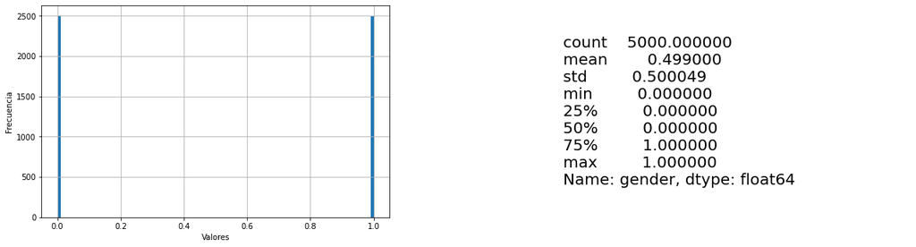

```python
histo_des(df['gender'])
```

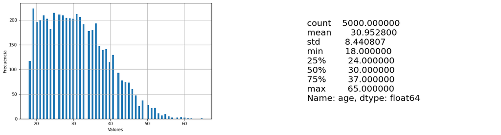

```python
histo_des(df['age'])
```

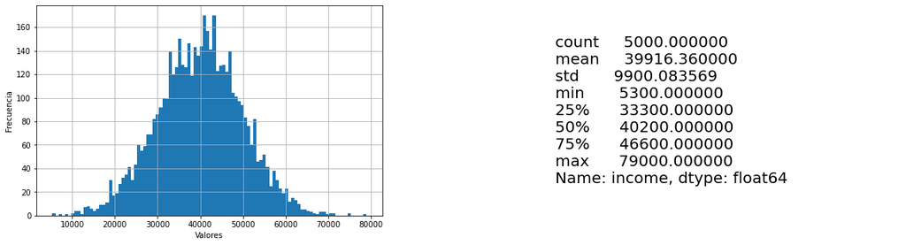

```python
histo_des(df['income'])
```

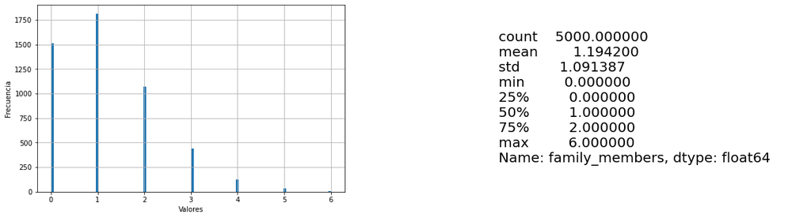

```python
histo_des(df['family_members'])
```

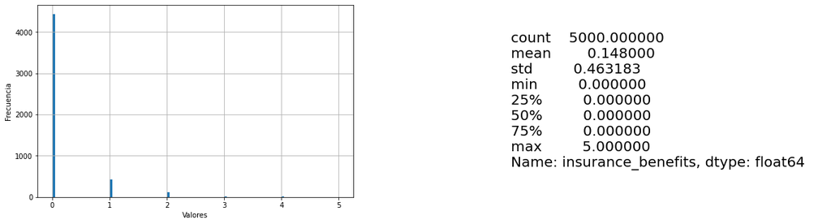

```python
histo_des(df['insurance_benefits'])
```

Los datos se encuentran dentro de los valores esperados.

## Análisis exploratorio de datos

Vamos a comprobar rápidamente si existen determinados grupos de clientes observando el gráfico de pares.

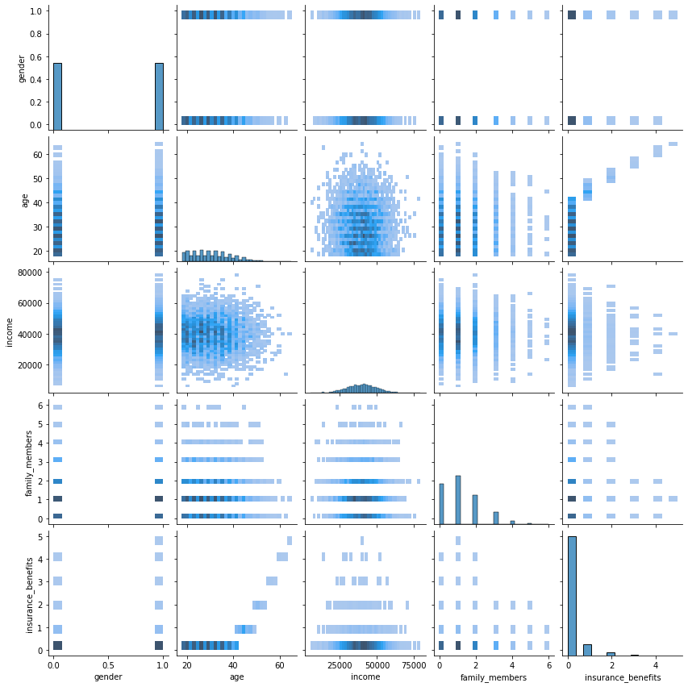

```python
g = sns.pairplot(df, kind='hist')
g.fig.set_size_inches(12, 12)
```

## Tarea 1. Clientes similares

En el lenguaje de ML, existe un procedimiento que devuelve los k vecinos más cercanos para un objeto dado basándose en la distancia entre ellos.

Para resolver la tarea, probaremos dos metricas diferentes de distancia, la distancia euclidiana y la distancia por bloques (Manhattan).

A continuación escribiré una función que devuelva los k vecinos más cercanos para un $n^{th}$ objeto basándose en una métrica de distancia especificada. A la hora de realizar esta tarea no consideraremos el número de prestaciones de seguro recibidas. Para realizar esta tarea, usaré un algoritmo kNN ya existente de la libreria scikit-learn.

Una vez creada la función, la probaré para cuatro combinaciones distintas, las cuales son:

- Distancia Euclidiana con datos normales
- Distancias Euclidiana con datos escalados (normalizados)
- Distancia Manhattan con datos normales
- Distancias Manhattan con datos escalados (normalizados)

```python
feature_names = ['gender', 'age', 'income', 'family_members']
#Creamos nuestra función para deterninar los k vecinos mas cercanos
def get_knn(df, n, k, metric):

    """
    Devuelve los k vecinos más cercanos

    :param df: DataFrame de pandas utilizado para encontrar objetos similares dentro del mismo lugar
    :param n: indice del objeto para los que se buscan los "k" vecinos más cercanos
    :param k: número de vecinos más cercanos a devolver
    :param métrica: nombre de la métrica de distancia    """


    nbrs = NearestNeighbors(metric=metric)
    nbrs.fit(df[feature_names])

    nbrs_distances, nbrs_indices = nbrs.kneighbors([df.iloc[n][feature_names]], k, return_distance=True)

    df_res = pd.concat([
        df.iloc[nbrs_indices[0]],
        pd.DataFrame(nbrs_distances.T, index=nbrs_indices[0], columns=['distance'])
        ], axis=1)

    return df_res
```

A continuación escalaremos (normalizaremos) nuestras caracteristicas y las almacenaremos en un nuevo dataframe llamado `df_scaled`

```python
feature_names = ['gender', 'age', 'income', 'family_members']

transformer_mas = sklearn.preprocessing.MaxAbsScaler().fit(df[feature_names].to_numpy())

df_scaled = df.copy()
df_scaled.loc[:, feature_names] = transformer_mas.transform(df[feature_names].to_numpy())
```

```python
df_scaled.sample(5)
```

|  | gender | age | income | family_members | insurance_benefits |
| --- | --- | --- | --- | --- | --- |
| 789 | 0.0 | 0.446154 | 0.508861 | 0.000000 | 0 |
| 3733 | 1.0 | 0.492308 | 0.583544 | 0.166667 | 0 |
| 1650 | 1.0 | 0.507692 | 0.511392 | 0.000000 | 0 |
| 2948 | 1.0 | 0.415385 | 0.455696 | 0.000000 | 0 |
| 2524 | 1.0 | 0.630769 | 0.431646 | 0.000000 | 0 |

Lo datos fueron escalados correctamente.

### Distancias euclideanas mas cercanas (datos sin escalar)

```python
#Calculamos las 5 distancias euclideanas mas cercanas para el objeto 39 del df sin escalar
#n=39, k=5
get_knn(df, 39, 5, 'euclidean')
```

|  | gender | age | income | family_members | insurance_benefits | distance |
| --- | --- | --- | --- | --- | --- | --- |
| 39 | 1 | 33 | 19400.0 | 1 | 0 | 0.000000 |
| 630 | 1 | 20 | 19400.0 | 2 | 0 | 13.038405 |
| 1334 | 0 | 32 | 19300.0 | 1 | 0 | 100.010000 |
| 1174 | 1 | 30 | 19300.0 | 1 | 0 | 100.044990 |
| 3445 | 0 | 37 | 19300.0 | 2 | 0 | 100.089960 |

```python
#Calculamos las 5 distancias manhattan mas cercanas para el objeto 39 del df sin escalar
#n=39, k=5
get_knn(df, 39, 5, 'cityblock')
```

|  | gender | age | income | family_members | insurance_benefits | distance |
| --- | --- | --- | --- | --- | --- | --- |
| 39 | 1 | 33 | 19400.0 | 1 | 0 | 0.0 |
| 630 | 1 | 20 | 19400.0 | 2 | 0 | 14.0 |
| 1334 | 0 | 32 | 19300.0 | 1 | 0 | 102.0 |
| 1174 | 1 | 30 | 19300.0 | 1 | 0 | 103.0 |
| 3445 | 0 | 37 | 19300.0 | 2 | 0 | 106.0 |

```python
#Calculamos las 5 distancias euclideanas mas cercanas para el objeto 39 del df escalado
#n=39, k=5
get_knn(df_scaled, 39, 5, 'euclidean')
```

|  | gender | age | income | family_members | insurance_benefits | distance |
| --- | --- | --- | --- | --- | --- | --- |
| 39 | 1.0 | 0.507692 | 0.245570 | 0.166667 | 0 | 0.000000 |
| 4454 | 1.0 | 0.492308 | 0.254430 | 0.166667 | 0 | 0.017754 |
| 1005 | 1.0 | 0.523077 | 0.272152 | 0.166667 | 0 | 0.030713 |
| 418 | 1.0 | 0.507692 | 0.278481 | 0.166667 | 0 | 0.032911 |
| 4370 | 1.0 | 0.492308 | 0.275949 | 0.166667 | 0 | 0.034053 |

### Distancias Manhattan mas cercanas (datos escalados)

```python
#Calculamos las 5 distancias manhattan mas cercanas para el objeto 39 del df escalado
#n=39, k=5
get_knn(df_scaled, 39, 5, 'cityblock')
```

|  | gender | age | income | family_members | insurance_benefits | distance |
| --- | --- | --- | --- | --- | --- | --- |
| 39 | 1.0 | 0.507692 | 0.245570 | 0.166667 | 0 | 0.000000 |
| 4454 | 1.0 | 0.492308 | 0.254430 | 0.166667 | 0 | 0.024245 |
| 418 | 1.0 | 0.507692 | 0.278481 | 0.166667 | 0 | 0.032911 |
| 1005 | 1.0 | 0.523077 | 0.272152 | 0.166667 | 0 | 0.041967 |
| 4370 | 1.0 | 0.492308 | 0.275949 | 0.166667 | 0 | 0.045764 |

**¿El hecho de que los datos no estén escalados afecta al algoritmo kNN? Si es así, ¿cómo se manifiesta?**

El hecho de que los datos no esten escalados afecta al cálculo de las "k" caracteristicas mas cercanas, ya que las caracteristicas con magnitudes grandes influyen en mayor magnitud respecto a las magnitudes mas pequeñas. Esto se puede ver claramente en las pruebas anteriores, en donde, al calcular las distancias sin escalar, la caracteristica `income` que es significativamente mas grande que el resto, influye casi totalmente en el calculo de la distancia.

**¿Qué tan similares son los resultados al utilizar la métrica de distancia Manhattan (independientemente del escalado)?**

Al comparar las distancias euclideanas con las manhattan, las de manhattan son mas grandes que las euclideas.

## Tarea 2. ¿Es probable que el cliente reciba una prestación del seguro?

En términos de machine learning podemos considerarlo como una tarea de clasificación binaria.

Con el valor de `insurance_benefits`, evaluaré si el enfoque de clasificación kNN puede funcionar mejor que el modelo dummy.

Pasos:

- Construiré un clasificador basado en KNN y medire su calidad con la métrica F1 para k=1...10 tanto para los datos originales como para los escalados. Observaremos cómo k puede influir en la métrica de evaluación y si el escalado de los datos provoca alguna diferencia. Para esta tarea utilizaré una implementación ya existente del algoritmo de clasificación kNN de scikit-learn
- Construiré un modelo dummy que, en este caso, es simplemente un modelo aleatorio. Este modelo devolverá "1" con cuatros probabilidades diferentes:
  - Probabilidad 0 (solo ceros)
  - Probabilidad de pagar cualquier prestación del seguro (ver formula mas abajo)
  - Probabilidad 0.5 (mitad de ceros y mitad de unos)
  - Probabilidad 1 (solo unos)

La probabilidad de pagar cualquier prestación del seguro puede definirse como $$ P\{\text{prestación de seguro recibida}\}=\frac{\text{número de clientes que han recibido alguna prestación de seguro}}{\text{número total de clientes}}. $$

Para las etapas de entrenamiento/prueba, dividiré los datos respetando la proporción 70:30.

```python
# Creamos una nueva columna para transformar la tarea en una clasificación binaria
# 0 si no tiene beneficios, 1 si tiene uno o mas beneficios
df['insurance_benefits_received'] = np.where(df['insurance_benefits'] > 0, 1, 0)
```

Una vez creada la columna objetivo, vemos si esta se encuentra balanceada.

```python
# compruebamos el desequilibrio de clases con value_counts()
df['insurance_benefits_received'].value_counts()
```

```
0    4436
1     564
Name: insurance_benefits_received, dtype: int64
```

Nuestra variable objetivo no se encuentra balanceada ya que tenemos muchas clasificaciones 0 y muy pocas 1. Es necesario balancear para que el desempeño de nuestro modelo sea adecuado. Para realizar el balanceo, aplicaré dos tecnicas, submuestreo y sobremuestreo, la primera elimina un pequeño porcentaje los valores objetivo (ceros) que se encuentra en mayor cantidad, mientras que la segunda, repite algunas muestras de los valores objetivo que se encuentran en menor cantidad (unos). Las funciones que aplican estas tecnicas serán definidas a continuación:

```python
#Submuestreo
def downsample(features, target, fraction):
    features_zeros = features[target == 0]
    features_ones = features[target == 1]
    target_zeros = target[target == 0]
    target_ones = target[target == 1]

    features_downsampled = pd.concat(
        [features_zeros.sample(frac=fraction, random_state=12345)]
        + [features_ones])

    target_downsampled = pd.concat(
        [target_zeros.sample(frac=fraction, random_state=12345)]
        + [target_ones])

    features_downsampled, target_downsampled = shuffle(features_downsampled, target_downsampled, random_state=12345)

    return features_downsampled, target_downsampled
```

```python
#Sobremuestreo
def upsample(features, target, repeat):
    features_zeros = features[target == 0]
    features_ones = features[target == 1]
    target_zeros = target[target == 0]
    target_ones = target[target == 1]

    features_upsampled = pd.concat([features_zeros] + [features_ones] * repeat)
    target_upsampled = pd.concat([target_zeros] + [target_ones] * repeat)

    features_upsampled, target_upsampled = shuffle(
        features_upsampled, target_upsampled, random_state=12345)

    return features_upsampled, target_upsampled
```

Dividimos los datos:

```python
#Separamos los conjuntos de entrenamiento y validacion (70:30)
train, valid = train_test_split(df, test_size=0.3, random_state=12345)

features_train = train.drop(['insurance_benefits','insurance_benefits_received'], axis=1)
target_train = train['insurance_benefits_received']

features_valid = valid.drop(['insurance_benefits','insurance_benefits_received'], axis=1)
target_valid = valid['insurance_benefits_received']
```

```python
target_train.value_counts()
```

```
0    3099
1     401
Name: insurance_benefits_received, dtype: int64
```

Como ya anticipamos, nuestros conjunto de entrenamiento tiene muchos mas ceros que unos en su objetivos, procedemos a balancear.

```python
#Duplicamos algunas muestras aleatorias de unos de forma de tener 6 veces mas unos
features_train,target_train = upsample(features_train, target_train, 6)
#Eliminamos aleatoriamente un 20% de los ceros
features_train,target_train = downsample(features_train, target_train, 0.8)
```

```python
target_train.value_counts()
```

```
0    2479
1    2406
Name: insurance_benefits_received, dtype: int64
```

Nuestro set de entrenamiento esta listo para ser utilizado.

Por último, construyo una función evaludora, la cual calcula metrica f1 y construye una matriz de confusión.

```python
def eval_classifier(y_true, y_pred):
    f1_score = sklearn.metrics.f1_score(y_true, y_pred)
    print(f'F1: {f1_score:.2f}')

    cm = sklearn.metrics.confusion_matrix(y_true, y_pred, normalize='all')
    print('Matriz de confusión')
    print(cm)
```

### Clasificador basado en KNN

```python
#Calculamos los k vecinos mas cercanos de nuestras caracteristicas para intentar predecir su clasificación
#probamos para distintas cantidad de vecinos (1....10)
#Evaluamos el desempeño de la predicción usando la metrica F1
for k in range(1,11):
    neigh = KNeighborsClassifier(n_neighbors=k)
    neigh.fit(features_train, target_train)
    predict_knn=neigh.predict(features_valid)

    #f1_score = sklearn.metrics.f1_score(target_valid, predict_knn)
    #print(f'F1 (k={k}): {f1_score:.2f}')
    print(f'k={k}:')
    eval_classifier(target_valid, predict_knn)
```

```
k=1:
F1: 0.60
Matriz de confusión
[[0.86333333 0.028     ]
 [0.05066667 0.058     ]]
k=2:
F1: 0.60
Matriz de confusión
[[0.86333333 0.028     ]
 [0.05066667 0.058     ]]
k=3:
F1: 0.54
Matriz de confusión
[[0.82733333 0.064     ]
 [0.044      0.06466667]]
k=4:
F1: 0.55
Matriz de confusión
[[0.828      0.06333333]
 [0.044      0.06466667]]
k=5:
F1: 0.47
Matriz de confusión
[[0.77133333 0.12      ]
 [0.03933333 0.06933333]]
k=6:
F1: 0.47
Matriz de confusión
[[0.77133333 0.12      ]
 [0.03933333 0.06933333]]
k=7:
F1: 0.43
Matriz de confusión
[[0.72133333 0.17      ]
 [0.03266667 0.076     ]]
k=8:
F1: 0.43
Matriz de confusión
[[0.72266667 0.16866667]
 [0.03266667 0.076     ]]
k=9:
F1: 0.39
Matriz de confusión
[[0.674      0.21733333]
 [0.02933333 0.07933333]]
k=10:
F1: 0.39
Matriz de confusión
[[0.674      0.21733333]
 [0.02933333 0.07933333]]
```

Ahora probamos con data escalada

```python
df_scaled['insurance_benefits_received'] = np.where(df['insurance_benefits'] > 0, 1, 0)

#Separamos los conjuntos de entrenamiento y validacion (70:30)
train, valid = train_test_split(df_scaled, test_size=0.3, random_state=12345)

features_train = train.drop(['insurance_benefits','insurance_benefits_received'], axis=1)
target_train = train['insurance_benefits_received']

features_valid = valid.drop(['insurance_benefits','insurance_benefits_received'], axis=1)
target_valid = valid['insurance_benefits_received']

features_train,target_train = upsample(features_train, target_train, 6)
features_train,target_train = downsample(features_train, target_train, 0.8)

for k in range(1,11):
    neigh = KNeighborsClassifier(n_neighbors=k)
    neigh.fit(features_train, target_train)
    predict_knn=neigh.predict(features_valid)

    #f1_score = sklearn.metrics.f1_score(target_valid, predict_knn)
    #print(f'F1 (k={k}): {f1_score:.2f}')

    print(f'k={k}:')
    eval_classifier(target_valid, predict_knn)
```

```
k=1:
F1: 0.95
Matriz de confusión
[[0.88533333 0.006     ]
 [0.00466667 0.104     ]]
k=2:
F1: 0.95
Matriz de confusión
[[0.88533333 0.006     ]
 [0.00466667 0.104     ]]
k=3:
F1: 0.91
Matriz de confusión
[[0.874      0.01733333]
 [0.00333333 0.10533333]]
k=4:
F1: 0.91
Matriz de confusión
[[0.874      0.01733333]
 [0.00333333 0.10533333]]
k=5:
F1: 0.88
Matriz de confusión
[[0.864      0.02733333]
 [0.00133333 0.10733333]]
k=6:
F1: 0.88
Matriz de confusión
[[0.864      0.02733333]
 [0.00133333 0.10733333]]
k=7:
F1: 0.87
Matriz de confusión
[[0.85933333 0.032     ]
 [0.         0.10866667]]
k=8:
F1: 0.87
Matriz de confusión
[[0.85933333 0.032     ]
 [0.         0.10866667]]
k=9:
F1: 0.84
Matriz de confusión
[[0.85133333 0.04      ]
 [0.         0.10866667]]
k=10:
F1: 0.84
Matriz de confusión
[[0.85133333 0.04      ]
 [0.         0.10866667]]
```

Respecto a las pruebas anteriores, vemos que la data escalada muestra un desempeño considerablemente superior a la data sin escalar. Esto tiene sentido, ya que en el primer caso, la columna `income` posee valores demasiado grandes que de no ser escalados, terminan influyendo casi en la totalidad la distancia de los vecinos, independientemente de los valores del resto de las caracteristicas.

### Clasificador dummy

A continuación crearé una función que arroje una predicción de 1 o 0 con una probabilidad P determinada.

```python
# generar la salida de un modelo aleatorio
def rnd_model_predict(P, size, seed=42):
    rng = np.random.default_rng(seed=seed)
    return rng.binomial(n=1, p=P, size=size)
```

Probabamos nuestros clasificador dummy para las cuatro probabilidades deseadas.

```python
for P in [0, df['insurance_benefits_received'].sum() / len(df), 0.5, 1]:

    print(f'La probabilidad: {P:.2f}')
    y_pred_rnd = rnd_model_predict(P, len(df)) # <tu código aquí>
    eval_classifier(y_pred_rnd,df['insurance_benefits_received'])

    print()
```

```
La probabilidad: 0.00
F1: 0.00
Matriz de confusión
[[0.8872 0.1128]
 [0.     0.    ]]

La probabilidad: 0.11
F1: 0.12
Matriz de confusión
[[0.7914 0.0994]
 [0.0958 0.0134]]

La probabilidad: 0.50
F1: 0.20
Matriz de confusión
[[0.456  0.053 ]
 [0.4312 0.0598]]

La probabilidad: 1.00
F1: 0.20
Matriz de confusión
[[0.     0.    ]
 [0.8872 0.1128]]
```

Como era de esperarse, nuestro clasificador kNN muestra un desempeño muy por encima de un modelo aleatorio.

## Tarea 3. Regresión (con regresión lineal)

A continuación, en vez de reducir `insurance_benefits` a un problema de clasificación simple, usaré un modelo de regresión lineal con `insurance_benefits` como objetivo. Para evaluar el modelo, lo evalurea con la metrica RECM.

Para esto, construiré una clase personalizada de regresión lineal teniendo en cuenta lo siguiente:

Denotemos

- $X$: matriz de características; cada fila es un caso, cada columna es una característica, la primera columna está formada por unidades
- $y$ — objetivo (un vector)
- $\hat{y}$ — objetivo estimado (un vector)
- $w$ — vector de pesos

La tarea de regresión lineal en el lenguaje de las matrices puede formularse así: $$ y = Xw $$

El objetivo de entrenamiento es entonces encontrar esa $w$ que minimice la distancia L2 (ECM) entre $Xw$ y $y$:

$$ \min_w d_2(Xw, y) \quad \text{or} \quad \min_w \text{MSE}(Xw, y) $$

Parece que hay una solución analítica para lo anteriormente expuesto: $$ w = (X^T X)^{-1} X^T y $$

La fórmula anterior puede servir para encontrar los pesos $w$ y estos últimos pueden utilizarse para calcular los valores predichos $$ \hat{y} = X_{val}w $$

Creación de la clase de regresión Lineal:

```python
class MyLinearRegression:

    def __init__(self):

        self.weights = None

    def fit(self, X, y):

        # añadir las unidades
        X2 = np.append(np.ones([len(X), 1]), X, axis=1)
        #self.weights = np.dot(X2.T,X2) # X transpuesta por X
        #self.weights = np.linalg.inv(self.weights) #Invierto el resultado anterior
        #self.weights = np.dot(self.weights,X2.T) #Lo multiplico con X transpuesta
        #self.weights = np.dot(self.weights,y) #Lo multiplico por el vector y

        self.weights = np.linalg.inv(X2.T.dot(X2)).dot(X2.T).dot(y) #Lo mismo que esta comentado arriba pero en menos pasos

        self.w0 = self.weights[0]
        self.weights = self.weights[1:]

    def predict(self, X):

        # añadir las unidades
        X2 = X
        y_pred = X2.dot(self.weights) + self.w0

        return y_pred
```

Nuestro modelo será evaluado con las metricas RECM(RMSE) y R2:

```python
def eval_regressor(y_true, y_pred):

    rmse = math.sqrt(sklearn.metrics.mean_squared_error(y_true, y_pred))
    print(f'RMSE: {rmse:.2f}')

    r2_score = math.sqrt(sklearn.metrics.r2_score(y_true, y_pred))
    print(f'R2: {r2_score:.2f}')
```

```python
#Preparamos la data sin escalar
X = df[['age', 'gender', 'income', 'family_members']].to_numpy()
y = df['insurance_benefits'].to_numpy()

#Separamos nuestra data en train, validacion (70:30)
X_train, X_test, y_train, y_test = train_test_split(X, y, test_size=0.3, random_state=12345)

#Definimos nuestro modelo en la variable lr
lr = MyLinearRegression()

#Entrenamos
lr.fit(X_train, y_train)
print(lr.weights)

#Evaluamos
y_test_pred = lr.predict(X_test)
eval_regressor(y_test, y_test_pred)
```

```
[ 3.57495491e-02  1.64272726e-02 -2.60743659e-07 -1.16902127e-02]
RMSE: 0.34
R2: 0.66
```

Ahora con datos escalados

```python
#Preparamos la data escalada
X = df_scaled[['age', 'gender', 'income', 'family_members']].to_numpy()
y = df_scaled['insurance_benefits'].to_numpy()

#Separamos nuestra data en train, validacion (70:30)
X_train, X_test, y_train, y_test = train_test_split(X, y, test_size=0.3, random_state=12345)

#Definimos nuestro modelo en la variable lr
lr = MyLinearRegression()

#Entrenamos
lr.fit(X_train, y_train)
print(lr.weights)

#Evaluamos
y_test_pred = lr.predict(X_test)
eval_regressor(y_test, y_test_pred)
```

```
[ 2.32372069  0.01642727 -0.02059875 -0.07014128]
RMSE: 0.34
R2: 0.66
```

Una vez entrenado y probado nuestro modelo tanto con los datos sin escalar, como escalados vemos que las metricas RMSE y R2 son identicas, independientemente de si las caracteristica estan escaladas o no. Lo que un indicio de que el entrenamiento del modelo de regresión lineal no se ve afectado por la escala de los datos.

Esto puede deberse a que la naturaleza del modelo de regresión lineal implica que las relaciones lineales entre las características y la variable objetivo se mantienen consistentes sin importar la escala de los datos.

Sin embargo, aunque las métricas se mantengan constantes, es importante destacar que el vector de pesos $w$ del modelo sí cambia dependiendo de si los datos están escalados o no. Cuando los datos están escalados, algunas características pueden tener una mayor influencia en la predicción debido a su mayor magnitud, lo que resulta en una asignación de pesos más equilibrada. En contraste, si las características no están escaladas, aquellas con magnitudes más grandes pueden dominar en la determinación de los pesos, lo que puede dar la impresión de que el modelo se ve afectado por la escala.

## Tarea 4. Ofuscar datos

Una de las solicitudes del cliente es mantener la privacidad de los datos del cliente. Para esto, lo mejor es ofuscar los datos multiplicando las características numéricas por una matriz invertible $P$.

$$ X' = X \times P $$

```python
#Definimos nuestras caracteristicas
personal_info_column_list = ['gender', 'age', 'income', 'family_members']
df_pn = df[personal_info_column_list]
```

```python
#Las transformamos a un vector "X"
X = df_pn.to_numpy()
X
```

```
array([[1.00e+00, 4.10e+01, 4.96e+04, 1.00e+00],
       [0.00e+00, 4.60e+01, 3.80e+04, 1.00e+00],
       [0.00e+00, 2.90e+01, 2.10e+04, 0.00e+00],
       ...,
       [0.00e+00, 2.00e+01, 3.39e+04, 2.00e+00],
       [1.00e+00, 2.20e+01, 3.27e+04, 3.00e+00],
       [1.00e+00, 2.80e+01, 4.06e+04, 1.00e+00]])
```

Generamos una matriz aleatoria $P$.

```python
rng = np.random.default_rng(seed=42)
P = rng.random(size=(X.shape[1], X.shape[1]))
P
```

```
array([[0.77395605, 0.43887844, 0.85859792, 0.69736803],
       [0.09417735, 0.97562235, 0.7611397 , 0.78606431],
       [0.12811363, 0.45038594, 0.37079802, 0.92676499],
       [0.64386512, 0.82276161, 0.4434142 , 0.22723872]])
```

Comprobamos que la matriz P sea invertible

```python
Pinv=np.linalg.inv(P)
Pinv #Almacenamos nuestra matriz P invertida
```

```
array([[ 0.41467992, -1.43783972,  0.62798546,  1.14001268],
       [-1.06101789,  0.44219337,  0.1329549 ,  1.18425933],
       [ 1.42362442,  1.60461607, -2.0553823 , -1.53699695],
       [-0.11128575, -0.65813802,  1.74995517, -0.11816316]])
```

Multiplicamos la matriz con las caracteristicas por nuestra matriz $P$.

```python
X2=np.dot(X,P)
X2
```

```
array([[ 6359.71527314, 22380.40467609, 18424.09074184, 46000.69669016],
       [ 4873.29406479, 17160.36702982, 14125.78076133, 35253.45577301],
       [ 2693.11742928,  9486.397744  ,  7808.83156024, 19484.86063067],
       ...,
       [ 4346.2234249 , 15289.24126492, 12586.16264392, 31433.50888552],
       [ 4194.09324155, 14751.9910242 , 12144.02930637, 30323.88763426],
       [ 5205.46827354, 18314.24814446, 15077.01370762, 37649.59295455]])
```

En este punto la información de los usuarios que se encuentra en la matriz X2 es irreconocible.

Segun la teoria, podemos recuperar la matriz original $X$ multiplicando la matriz $X2$ por la matriz inversa de $P$. Comprobaremos esto a continación:

```python
X_recuperado=np.dot(X2,Pinv)
X_recuperado = np.round(X_recuperado, decimals=8) #redondeo a 8 decimales para eliminar los errores de calculo
X_recuperado
```

```
array([[ 1.00e+00,  4.10e+01,  4.96e+04,  1.00e+00],
       [-0.00e+00,  4.60e+01,  3.80e+04,  1.00e+00],
       [-0.00e+00,  2.90e+01,  2.10e+04,  0.00e+00],
       ...,
       [-0.00e+00,  2.00e+01,  3.39e+04,  2.00e+00],
       [ 1.00e+00,  2.20e+01,  3.27e+04,  3.00e+00],
       [ 1.00e+00,  2.80e+01,  4.06e+04,  1.00e+00]])
```

Comparemos las 3 matrices ($X$, $X2$ y $Xrecuperado$)

Matriz $X$ original

```python
pd.DataFrame(X, columns=personal_info_column_list)
```

|  | gender | age | income | family_members |
| --- | --- | --- | --- | --- |
| 0 | 1.0 | 41.0 | 49600.0 | 1.0 |
| 1 | 0.0 | 46.0 | 38000.0 | 1.0 |
| 2 | 0.0 | 29.0 | 21000.0 | 0.0 |
| 3 | 0.0 | 21.0 | 41700.0 | 2.0 |
| 4 | 1.0 | 28.0 | 26100.0 | 0.0 |
| ... | ... | ... | ... | ... |
| 4995 | 0.0 | 28.0 | 35700.0 | 2.0 |
| 4996 | 0.0 | 34.0 | 52400.0 | 1.0 |
| 4997 | 0.0 | 20.0 | 33900.0 | 2.0 |
| 4998 | 1.0 | 22.0 | 32700.0 | 3.0 |
| 4999 | 1.0 | 28.0 | 40600.0 | 1.0 |

5000 rows × 4 columns

Matriz $X$ ofuscada (aqui la data es irreconocible)

```python
pd.DataFrame(X2, columns=personal_info_column_list)
```

|  | gender | age | income | family_members |
| --- | --- | --- | --- | --- |
| 0 | 6359.715273 | 22380.404676 | 18424.090742 | 46000.696690 |
| 1 | 4873.294065 | 17160.367030 | 14125.780761 | 35253.455773 |
| 2 | 2693.117429 | 9486.397744 | 7808.831560 | 19484.860631 |
| 3 | 5345.603937 | 18803.227203 | 15479.148373 | 38663.061863 |
| 4 | 3347.176735 | 11782.829283 | 9699.998942 | 24211.273378 |
| ... | ... | ... | ... | ... |
| 4995 | 4577.581382 | 16107.740932 | 13259.688205 | 33107.974380 |
| 4996 | 6717.000247 | 23634.217067 | 19456.138634 | 48589.438841 |
| 4997 | 4346.223425 | 15289.241265 | 12586.162644 | 31433.508886 |
| 4998 | 4194.093242 | 14751.991024 | 12144.029306 | 30323.887634 |
| 4999 | 5205.468274 | 18314.248144 | 15077.013708 | 37649.592955 |

5000 rows × 4 columns

Matriz $X$ recuperada

```python
pd.DataFrame(X_recuperado, columns=personal_info_column_list)
```

|  | gender | age | income | family_members |
| --- | --- | --- | --- | --- |
| 0 | 1.0 | 41.0 | 49600.0 | 1.0 |
| 1 | -0.0 | 46.0 | 38000.0 | 1.0 |
| 2 | -0.0 | 29.0 | 21000.0 | 0.0 |
| 3 | -0.0 | 21.0 | 41700.0 | 2.0 |
| 4 | 1.0 | 28.0 | 26100.0 | -0.0 |
| ... | ... | ... | ... | ... |
| 4995 | -0.0 | 28.0 | 35700.0 | 2.0 |
| 4996 | -0.0 | 34.0 | 52400.0 | 1.0 |
| 4997 | -0.0 | 20.0 | 33900.0 | 2.0 |
| 4998 | 1.0 | 22.0 | 32700.0 | 3.0 |
| 4999 | 1.0 | 28.0 | 40600.0 | 1.0 |

5000 rows × 4 columns

Se aprecia que algunos valores de la matriz recuperada no son exactamente iguales a los de los datos originales. ¿Cuál podría ser la razón de ello?

Lo valores de la matriz X recuperada no son exactamente igual a la matriz X original debido a la naturaleza de las operaciones con números en punto flotante, sin embargo estos errores son significativamente pequeños(del orden de magnitud de la precisión de máquina), por lo que al aplicar una aproximación de 8 decimales, tal y como se hizo mas arriba, es suficiente para virtualmente eliminar estas diferencias.

### Prueba de que la ofuscación de datos puede funcionar con regresión lineal

La tarea de regresión se ha resuelto con la regresión lineal. A continuación demostraré *analiticamente* que el método de ofuscación no afectará a la regresión lineal en términos de valores predichos, es decir, que sus valores seguirán siendo los mismos tanto para una matriz normal, como para una ofuscada (codificada).

Una vez ofuscados los datos, tenemos $X \times P$ en lugar de tener solo $X$. En consecuencia, hay otros pesos $w_P$ como $$ w = (X^T X)^{-1} X^T y \quad \Rightarrow \quad w_P = [(XP)^T XP]^{-1} (XP)^T y $$

**Prueba analítica**

Si $w_P = [(XP)^T XP]^{-1} (XP)^T y$

Simplificando:

$ w_P = [(XP)^T XP]^{-1} (XP)^T y \quad/ *[(XP)^T XP] $ (a la izquierda)

$ [(XP)^T XP]w_P = [(XP)^T XP][(XP)^T XP]^{-1} (XP)^T y $

Donde $ I = [(XP)^T XP][(XP)^T XP]^{-1} $

Entonces $ (XP)^T XPw_P = (XP)^T y $

Simplificando (multiplicando por $[(XP)^T]^{-1}$ a la izquierda) y reordenando

$$ \begin{array}{|c|}\hline y =(XP)w_P \\ \hline \end{array} $$

Y como sabemos de antemano que:

$$ \begin{array}{|c|}\hline y = Xw \\ \hline \end{array} $$

Entonces la relacion en $w$ y $w_p$ es:

$$ \begin{array}{|c|}\hline w = Pw_P \\ \hline \end{array} $$

Considerando lo anterior:

Si tenemos $X$ y $X'$ donde $X'=XP$

Sabemos que la predición de la matriz $X$ es:

$ \hat{y} = Xw$ (1)

Mientras que la predicción de la matriz $X'$ (X ofuscada) es:

$ \hat{y_P} = X'w_P $

Entonces si reemplazamos $w = Pw_P$ en (1), obtenemos

$ \hat{y} = Xw = XPw_P = X'w_P = \hat{y_P} $

Por lo tanto, las predicciones del modelo entrenado con la matriz normal y el el modelo entrenado con la matriz ofuscada son equivalentes. $$ \begin{array}{|c|}\hline \hat{y} = \hat{y_P} \\ \hline \end{array} $$

Como vimos en la demostración anterior, la relación entre el vector $w$ y el vector $w_p$ es la multiplicación por la matriz $P$. Por lo tanto, los valores predichos tanto con el vector $w$ como con $w_p$ entregaran como resultado una predicción correcta.

### Prueba de regresión lineal con ofuscación de datos

Ahora, probemos que la regresión lineal pueda funcionar, en términos computacionales, con la transformación de ofuscación elegida. Construiré un procedimiento o una clase que ejecute la regresión lineal opcionalmente con la ofuscación. Esta vez, en vez de la clase creada, utilizaré el modelo de regresión lineal de scikit-learn. Ejecutaré la regresión lineal para los datos originales y los ofuscados y luego compararé los valores predichos y los valores de las métricas RMSE y $R^2$.

Creamos una matriz $P$.

```python
rng = np.random.default_rng(seed=42)
P = rng.random(size=(X.shape[1], X.shape[1]))
P
```

```
array([[0.77395605, 0.43887844, 0.85859792, 0.69736803],
       [0.09417735, 0.97562235, 0.7611397 , 0.78606431],
       [0.12811363, 0.45038594, 0.37079802, 0.92676499],
       [0.64386512, 0.82276161, 0.4434142 , 0.22723872]])
```

Comprabamos que esta sea invertible:

```python
Pinv=np.linalg.inv(P)
Pinv
```

```
array([[ 0.41467992, -1.43783972,  0.62798546,  1.14001268],
       [-1.06101789,  0.44219337,  0.1329549 ,  1.18425933],
       [ 1.42362442,  1.60461607, -2.0553823 , -1.53699695],
       [-0.11128575, -0.65813802,  1.74995517, -0.11816316]])
```

Defino una función que entrena y evalua el desempeño del modelo usando data ofuscada, o sin ofuscar, usando las metricas RMSE y R2. Ademas, muestra un dataframe con la caracteristicas de prueba, sus datos reales y sus predicciones.

```python
def probar_modelo(df,ofuscar):
    X = df[['age', 'gender', 'income', 'family_members']].to_numpy()
    y = df['insurance_benefits'].to_numpy()

    if ofuscar:
        X=np.dot(X,P)

    X_train, X_test, y_train, y_test = train_test_split(X, y, test_size=0.3, random_state=12345)
    lr = LinearRegression()
    lr.fit(X_train, y_train)

    y_test_pred = lr.predict(X_test)
    eval_regressor(y_test, y_test_pred)


    datos=pd.concat([
        pd.DataFrame(X_test, columns=['age','gender', 'income', 'family_members']),
        pd.DataFrame(y_test.T,  columns=['Objetivo(real)']),
        pd.DataFrame(y_test_pred.T,  columns=['Objetivo(prediccion)'])
        ], axis=1)

    if ofuscar:
        print ('Caracteristicas ofuscadas (encriptadas)')
        display(datos.head(30))
    else:
        print ('Caracteristicas reales')
        display(datos.head(30))
```

```python
probar_modelo(df,ofuscar=False)
```

```
RMSE: 0.34
R2: 0.66
Caracteristicas reales
```

|  | age | gender | income | family_members | Objetivo(real) | Objetivo(prediccion) |
| --- | --- | --- | --- | --- | --- | --- |
| 0 | 33.0 | 0.0 | 39000.0 | 4.0 | 0 | 0.179266 |
| 1 | 50.0 | 0.0 | 43100.0 | 2.0 | 2 | 0.809320 |
| 2 | 39.0 | 1.0 | 42100.0 | 0.0 | 0 | 0.456143 |
| 3 | 20.0 | 0.0 | 34800.0 | 0.0 | 0 | -0.237622 |
| 4 | 41.0 | 0.0 | 40000.0 | 4.0 | 0 | 0.465002 |
| 5 | 34.0 | 1.0 | 44800.0 | 0.0 | 0 | 0.276692 |
| 6 | 23.0 | 1.0 | 32200.0 | 5.0 | 0 | -0.171719 |
| 7 | 30.0 | 1.0 | 25000.0 | 1.0 | 0 | 0.127166 |
| 8 | 47.0 | 1.0 | 54200.0 | 3.0 | 1 | 0.703914 |
| 9 | 20.0 | 0.0 | 48200.0 | 1.0 | 0 | -0.252806 |
| 10 | 36.0 | 0.0 | 41700.0 | 1.0 | 0 | 0.320882 |
| 11 | 30.0 | 0.0 | 30700.0 | 4.0 | 0 | 0.074182 |
| 12 | 40.0 | 0.0 | 54600.0 | 1.0 | 0 | 0.460516 |
| 13 | 20.0 | 1.0 | 46600.0 | 1.0 | 0 | -0.235962 |
| 14 | 25.0 | 0.0 | 53900.0 | 2.0 | 0 | -0.087235 |
| 15 | 22.0 | 1.0 | 30600.0 | 3.0 | 0 | -0.183671 |
| 16 | 27.0 | 1.0 | 40100.0 | 2.0 | 0 | 0.004290 |
| 17 | 21.0 | 0.0 | 42200.0 | 2.0 | 0 | -0.227182 |
| 18 | 41.0 | 0.0 | 31400.0 | 1.0 | 0 | 0.502315 |
| 19 | 38.0 | 1.0 | 44400.0 | 0.0 | 0 | 0.419794 |
| 20 | 21.0 | 1.0 | 50200.0 | 0.0 | 0 | -0.189461 |
| 21 | 48.0 | 1.0 | 13800.0 | 2.0 | 1 | 0.761888 |
| 22 | 42.0 | 0.0 | 38700.0 | 1.0 | 1 | 0.536161 |
| 23 | 22.0 | 1.0 | 38000.0 | 1.0 | 0 | -0.162220 |
| 24 | 22.0 | 1.0 | 32700.0 | 3.0 | 0 | -0.184219 |
| 25 | 33.0 | 1.0 | 23800.0 | 1.0 | 0 | 0.234727 |
| 26 | 36.0 | 1.0 | 44600.0 | 1.0 | 0 | 0.336553 |
| 27 | 23.0 | 1.0 | 35500.0 | 2.0 | 0 | -0.137509 |
| 28 | 36.0 | 1.0 | 48700.0 | 1.0 | 0 | 0.335484 |
| 29 | 31.0 | 1.0 | 52900.0 | 0.0 | 0 | 0.167331 |

```python
probar_modelo(df,ofuscar=True)
```

```
RMSE: 0.34
R2: 0.66
Caracteristicas ofuscadas (encriptadas)
```

|  | age | gender | income | family_members | Objetivo(real) | Objetivo(prediccion) |
| --- | --- | --- | --- | --- | --- | --- |
| 0 | 5024.547684 | 17582.825613 | 14491.230333 | 36167.756665 | 0 | 0.179266 |
| 1 | 5561.683101 | 19435.223369 | 16025.211569 | 39978.893898 | 2 | 0.809320 |
| 2 | 5423.862399 | 18979.339867 | 15644.843279 | 39044.789448 | 0 | 0.456143 |
| 3 | 4473.833538 | 15682.208208 | 12920.943202 | 32265.368973 | 0 | -0.237622 |
| 4 | 5158.852965 | 18036.722578 | 14868.897141 | 37100.100598 | 0 | 0.465002 |
| 5 | 5765.899427 | 20193.187507 | 16641.704955 | 41543.568078 | 0 | 0.276692 |
| 6 | 4146.373464 | 14517.610835 | 11962.422343 | 29859.794364 | 0 | -0.171719 |
| 7 | 3226.797541 | 11274.613185 | 9296.913097 | 23191.059065 | 0 | 0.127166 |
| 8 | 6982.160598 | 24434.989028 | 20139.698398 | 50264.906473 | 1 | 0.703914 |
| 9 | 6191.200081 | 21718.202537 | 17890.080141 | 44684.247062 | 0 | -0.252806 |
| 10 | 5370.844765 | 18797.715996 | 15493.630550 | 38671.432523 | 0 | 0.320882 |
| 11 | 3958.882665 | 13843.305693 | 11411.030938 | 28473.515153 | 0 | 0.074182 |
| 12 | 7026.606451 | 24609.450108 | 20280.359454 | 50629.490351 | 0 | 0.460516 |
| 13 | 5986.312446 | 20998.560659 | 17297.564442 | 43202.209144 | 0 | -0.235962 |
| 14 | 6925.961433 | 24288.419537 | 20008.365283 | 49970.521577 | 0 | -0.087235 |
| 15 | 3939.329966 | 13794.908932 | 11367.400078 | 28375.818536 | 0 | -0.183671 |
| 16 | 5159.635391 | 18074.946973 | 14893.830884 | 37183.345531 | 0 | 0.004290 |
| 17 | 5423.936106 | 19017.148550 | 15666.594007 | 39124.581735 | 0 | -0.227182 |
| 18 | 4055.144129 | 14160.935228 | 11678.703890 | 29129.239978 | 0 | 0.502315 |
| 19 | 5717.749798 | 20014.788646 | 16496.820137 | 41175.651554 | 0 | 0.419794 |
| 20 | 6447.651615 | 22619.566152 | 18632.852512 | 46539.033233 | 0 | -0.189461 |
| 21 | 1806.499929 | 6239.013254 | 5159.873403 | 12824.071053 | 1 | 0.761888 |
| 22 | 4991.147604 | 17449.191453 | 14386.388065 | 35895.321764 | 1 | 0.536161 |
| 23 | 4886.083117 | 17126.119350 | 14110.418629 | 35233.424976 | 0 | -0.162220 |
| 24 | 4208.368594 | 14740.719402 | 12146.075929 | 30322.025012 | 0 | -0.184219 |
| 25 | 3075.383050 | 10735.466694 | 8854.531262 | 22081.033183 | 0 | 0.234727 |
| 26 | 5742.468478 | 20104.810838 | 16569.705960 | 41359.837055 | 0 | 0.336553 |
| 27 | 4567.216857 | 16001.416145 | 13184.725581 | 32917.437111 | 0 | -0.137509 |
| 28 | 6267.734372 | 21951.393183 | 18089.977859 | 45159.573509 | 0 | 0.335484 |
| 29 | 6801.297983 | 23839.996969 | 19642.593157 | 49048.272383 | 0 | 0.167331 |

Finalmente, vemos que el modelo de regresión lineal es capaz de predecir con la misma precisión caracteristicas normales como ofuscadas.

## Conclusiones

Tarea 1:

- El hecho de que los datos no esten escalados afecta signficativamente al cálculo de las "k" caracteristicas mas cercanas, ya que las caracteristicas con magnitudes grandes influyen en mayor magnitud respecto a las magnitudes mas pequeñas.
- Las distancias Manhattan SIEMPRE serán un poco mas largas que las distancias euclideanas.

Tarea 2:

Para el problema de clasificación binaria, como usamos el criterio de los vecinos cercanos para predecir nuestro objetivo, al igual que el punto anterior,la data escalada muestra un desempeño considerablemente superior a la data sin escalar. Esto tiene sentido, ya que las columna con valores demasiado grandes de de no ser escalados, terminan influyendo casi en la totalidad el calculo dela distancia, mientras que los valores del resto de las caracteristicas pasan a ser despreciables.

Tarea 3:

Para el caso del modelo de regresión lineal, una vez entrenado y probado tanto con los datos sin escalar, como escalados. En base a las metricas RMSE y R2, vemos que el desempeño del modelo es identico, independientemente de si esta escalado o no.

Tarea 4:

El modelo de regresión lineal es capaz de predecir correctamente y con la misma precisión caracteristicas normales como ofuscadas (encriptadas).

# Apéndices

## Apéndice A: Escribir fórmulas en los cuadernos de Jupyter

Puedes escribir fórmulas en tu Jupyter Notebook utilizando un lenguaje de marcado proporcionado por un sistema de publicación de alta calidad llamado $\LaTeX$ (se pronuncia como "Lah-tech"). Las fórmulas se verán como las de los libros de texto.

Para incorporar una fórmula a un texto, pon el signo de dólar (\$) antes y después del texto de la fórmula, por ejemplo: $\frac{1}{2} \times \frac{3}{2} = \frac{3}{4}$ or $y = x^2, x \ge 1$.

Si una fórmula debe estar en el mismo párrafo, pon el doble signo de dólar (\$\\$) antes y después del texto de la fórmula, por ejemplo: $$ \bar{x} = \frac{1}{n}\sum_{i=1}^{n} x_i. $$

El lenguaje de marcado de LaTeX es muy popular entre las personas que utilizan fórmulas en sus artículos, libros y textos. Puede resultar complicado, pero sus fundamentos son sencillos. Consulta esta [ficha de ayuda](http://tug.ctan.org/info/undergradmath/undergradmath.pdf) (materiales en inglés) de dos páginas para aprender a componer las fórmulas más comunes.

## Apéndice B: Propiedades de las matrices

Las matrices tienen muchas propiedades en cuanto al álgebra lineal. Aquí se enumeran algunas de ellas que pueden ayudarte a la hora de realizar la prueba analítica de este proyecto.

| Distributividad | $A(B+C)=AB+AC$ |
| --- | --- |
| No conmutatividad | $AB \neq BA$ |
| Propiedad asociativa de la multiplicación | $(AB)C = A(BC)$ |
| Propiedad de identidad multiplicativa | $IA = AI = A$ |
|  | $A^{-1}A = AA^{-1} = I$ |
|  | $(AB)^{-1} = B^{-1}A^{-1}$ |
| Reversibilidad de la transposición de un producto de matrices, | $(AB)^T = B^TA^T$ |